# Re-Analysis (simplified): bodyfat prediction

- Show All Code
- Hide All Code
- View Source

2024

Contrast-Bayes-Frequentist

STRATOS

R

Classification: confidential

Author

Affiliation

Mariana Nold

University of Jena, Institute of Sociology

Published

July 10, 2026

# 1 Preliminaries

This analysis report relates to SRe-API for the Analysis of bodyfat example (simplified).

## 1.1 Load libraries

```r
library("rstanarm")
library("projpred")
library("ggplot2")
library("loo")
library("bayesplot")
library("bayesrules")
library("DHARMa")
library("ggplot2")
library("dplyr")
library("tidyr")
library("patchwork")
library("posterior")
library("knitr")
library("kableExtra")
```

## 1.2 Helper Functions

```r
visualize_variable_selection <- function(vs_cvf) {

  # Extract the summary and store as return object
  model_summary <- summary(vs_cvf, deltas = FALSE, cumulate = FALSE)

  # Extract predictor ranking
  rk <- ranking(vs_cvf)

  # Compute variable ranking proportions
  pr_rk <- cv_proportions(rk)
  pr_rk2 <- cv_proportions(rk, cumulate = TRUE)
  # Generate plots
  gg_pr_rk <- plot(pr_rk) + theme(legend.position = "none")
  gg_pr_rk2 <- plot(pr_rk2) + theme(legend.position = "none")
  combined_plot <- gg_pr_rk / gg_pr_rk2


  # Return both the summary and the plot
  return(list(summary = model_summary, plot = combined_plot))
}

#' Extract and round a single model size row (e.g. "<=5") from cv_proportions
#'
#' @param cumprop Cumulative proportions matrix from cv_proportions(..., cumulate = TRUE)
#' @param size Integer value, the exact model size to extract (default: 5)
#' @param digits Number of decimal places to round to (default: 3)
#' @return A 1-row matrix with rounded values
get_cumprop_row_rounded <- function(cumprop, size = 5, digits = 3) {
  rowname <- paste0("<=", size)
  if (!(rowname %in% rownames(cumprop))) {
    stop(paste0("Model size '<=", size, "' not found in row names."))
  }
  row <- cumprop[rowname, , drop = FALSE]
  row[] <- round(row, digits = digits)
  return(row)
}


#' Inspect and summarize variable selection results
#'
#' This function provides a structured summary of variable selection output from
#' both Lasso and forward selection methods (e.g. via projpred). It visualizes
#' selection stability, shows cumulative selection proportions, and identifies
#' top predictors based on ranking and suggested model size.
#'
#' @param vs_object A variable selection object (e.g. result from cv_varsel())
#' @param top_n Number of top variables to display (default is 5)
#' @return A list containing summary, plot, ranking, top variables, and suggested terms

inspect_variable_selection <- function(vs_object, top_n = 5) {
  # Run visualization and show textual summary
  cat("\n Summary of variable selection:\n")
  result <- visualize_variable_selection(vs_object)
  print(result$summary)

  # Plot selection trace
  cat("\n️ Visualization of selection process:\n")
  print(result$plot)

  # Cumulative selection proportions for top_n terms
  cat(paste0("\n Cumulative selection proportions (Top ", top_n, "):\n"))
  cumprop <- cv_proportions(ranking(vs_object), cumulate = TRUE)
  rounded <- get_cumprop_row_rounded(cumprop, size = top_n)
  print(rounded)

  # Suggested model size based on selection criteria
  suggested <- suggest_size(vs_object)
  cat("\n Suggested model size:\n")
  print(suggested)

  # Full ranking table of all variables
  ranking_data <- ranking(vs_object)$fulldata
  cat("\n Full ranking table:\n")
  print(ranking_data)

  # Final selected terms based on suggested model size
  cat(paste0("\n Terms selected (suggested size = ", suggested, "):\n"))
  final_terms <- head(ranking_data, suggested)
  print(final_terms)

  # Display top_n terms (fixed number)
  cat(paste0("\n Top ", top_n, " ranked terms:\n"))
  top_terms <- head(ranking_data, top_n)
  print(top_terms)

  # Return all outputs invisibly for further use
  invisible(list(
    result = result,
    cumprop = rounded,
    suggested_size = suggested,
    full_ranking = ranking_data,
    final_terms = final_terms,
    top_terms = top_terms
  ))
}

# Computes posterior predictive distribution of Bayesian R² as defined by Gelman et al. (2019). for post-selection inference
# Measures the proportion of variance in the predictions (ypred) relative to total variance (predictions + residuals).
# The function returns a vector of R² values across posterior draws.
# Input:
#   - ypred: matrix of posterior linear predictions (rows = draws, columns = observations)
#   - y: vector of observed outcome values
# Output:
#   - r2: numeric vector of Bayesian R² values (one per draw)

bayes_r2 <- function(ypred, y) {
  resid <- sweep(ypred, 2, y)
  var_ypred <- apply(ypred, 1, var)
  var_resid <- apply(resid, 1, var)
  r2 <- var_ypred / (var_ypred + var_resid)
  return(r2)
}

# This function computes a posterior predictive distribution of Bayesian R².
# For each posterior predictive draw (each row of ypred), it calculates
# the coefficient of determination:
# R² = 1 - RSS / TSS, where RSS is the residual sum of squares between
# observed values and predicted values for that draw, and TSS is the
# total sum of squares around the observed mean.
#
# The function returns a vector of R² values, representing uncertainty
# in model fit across the posterior predictive distribution.
#
bayes_r2_ext <- function(ypred, y) {

  # compute mean of observed outcome
  ymean <- mean(y)

  # compute R² for each posterior predictive draw (row-wise)
  r2_val <- apply(ypred, 1, function(pred_row) {
    1 - sum((y - pred_row)^2) / sum((y - ymean)^2)
  })

  return(r2_val)
}
```

## 1.3 Load data

```r
load("../Datafiles/bodyfatdata.Rdata")
PPath <- "C:/Users/zo95yup/Documents/GitHub/Bayes_for_STRATOS/Task Bodyfat/"
```

# 2 Main data analysis

## 2.1 Define and fit reference model

```r
# Create the vector of predictor names
predictors <- c("Weight", "Height", "BMI", "Age",
  "Neck", "Chest", "Biceps", "Hips", "Waist",
  "Forearm", "MThigh", "Wrist",
  "Knee", "Ankle")

# Collapse the predictor names into a single string joined by +
rhs <- paste(predictors, collapse = " + ")

# Combine with the response variable to create a formula
rmf <- as.formula(paste("Fat ~", rhs))

# Fit a Bayesian Gaussian regression model using stan_glm
ref_fit <- stan_glm(rmf, data = women, family = gaussian())
```

```r
draws <- as.matrix(ref_fit)
# This function returns Rhat and n_eff diagnostics for each model parameter.
# Use it to evaluate convergence and sampling efficiency in Bayesian regression.
# Recommended threshold: Rhat < 1.01 and n_eff_bulk and n_eff_tail > 100 per chain for # reliable inference. see: https://mc-stan.org/rstan/reference/Rhat.html


diagnostics <- summarise_draws(draws)
diagnostics_tbl <- diagnostics[, c("variable", "rhat", "ess_bulk" , "ess_tail")]

kable(diagnostics_tbl, digits = 3, caption = "MCMC diagnostics") %>%
  kable_styling(full_width = FALSE)
```

MCMC diagnostics

| variable | rhat | ess_bulk | ess_tail |
| --- | --- | --- | --- |
| (Intercept) | 1.000 | 2008.157 | 2185.260 |
| Weight | 1.000 | 1979.445 | 2116.347 |
| Height | 1.000 | 1975.393 | 2200.805 |
| BMI | 1.000 | 2016.960 | 2210.688 |
| Age | 1.000 | 4177.762 | 2513.432 |
| Neck | 1.000 | 4333.976 | 3425.493 |
| Chest | 1.001 | 4307.827 | 3047.614 |
| Biceps | 1.000 | 3443.777 | 2676.811 |
| Hips | 1.000 | 4500.699 | 2954.597 |
| Waist | 1.000 | 3743.853 | 2925.687 |
| Forearm | 1.001 | 3114.215 | 2564.965 |
| MThigh | 1.000 | 4494.664 | 3224.020 |
| Wrist | 1.000 | 3606.276 | 2662.750 |
| Knee | 1.000 | 4110.023 | 2847.411 |
| Ankle | 1.001 | 4135.054 | 3076.244 |
| sigma | 1.000 | 5127.201 | 3395.387 |

```r
prior_summary(ref_fit) # https://cran.r-project.org/web/packages/rstanarm/vignettes/priors.html
```

```
Priors for model 'ref_fit'
------
Intercept (after predictors centered)
  Specified prior:
    ~ normal(location = 22, scale = 2.5)
  Adjusted prior:
    ~ normal(location = 22, scale = 15)

Coefficients
  Specified prior:
    ~ normal(location = [0,0,0,...], scale = [2.5,2.5,2.5,...])
  Adjusted prior:
    ~ normal(location = [0,0,0,...], scale = [  1.77,246.96,  5.38,...])

Auxiliary (sigma)
  Specified prior:
    ~ exponential(rate = 1)
  Adjusted prior:
    ~ exponential(rate = 0.17)
------
See help('prior_summary.stanreg') for more details
```

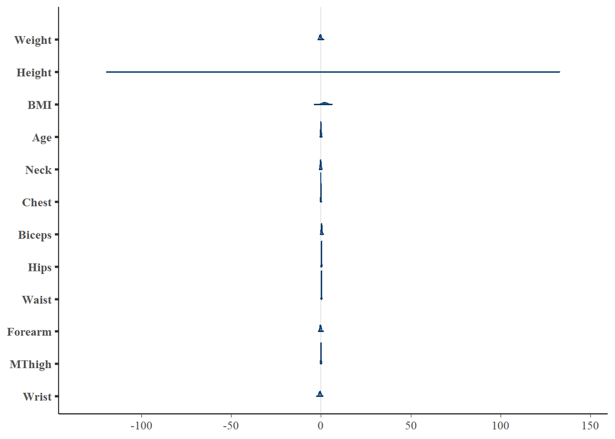

```r
mat_ref_fit <- as.matrix(ref_fit)
draws_ref_fit <- posterior::as_draws_matrix(mat_ref_fit)
mcmc_areas(mat_ref_fit[,2:13])
```

```r
summary_tbl_ref_fit <- summarise_draws(draws_ref_fit, mean, sd, median, ~quantile(.x, probs = c(0.05, 0.95)))
kable(summary_tbl_ref_fit, digits = 3, caption = "Posterior summary statistics")
```

Posterior summary statistics

| variable | mean | sd | median | 5% | 95% |
| --- | --- | --- | --- | --- | --- |
| (Intercept) | -58.152 | 59.630 | -56.809 | -154.531 | 41.095 |
| Weight | -0.396 | 0.499 | -0.387 | -1.209 | 0.432 |
| Height | 19.538 | 36.140 | 18.845 | -40.254 | 78.844 |
| BMI | 1.755 | 1.397 | 1.736 | -0.556 | 4.017 |
| Age | -0.040 | 0.176 | -0.043 | -0.332 | 0.255 |
| Neck | -0.177 | 0.266 | -0.179 | -0.611 | 0.245 |
| Chest | -0.070 | 0.091 | -0.072 | -0.216 | 0.082 |
| Biceps | 0.345 | 0.229 | 0.345 | -0.028 | 0.718 |
| Hips | 0.274 | 0.099 | 0.273 | 0.110 | 0.438 |
| Waist | 0.260 | 0.093 | 0.261 | 0.107 | 0.412 |
| Forearm | -0.275 | 0.398 | -0.281 | -0.919 | 0.370 |
| MThigh | 0.007 | 0.125 | 0.006 | -0.204 | 0.211 |
| Wrist | -0.615 | 0.537 | -0.608 | -1.504 | 0.290 |
| Knee | 0.510 | 0.219 | 0.510 | 0.150 | 0.873 |
| Ankle | -0.500 | 0.317 | -0.495 | -1.028 | 0.010 |
| sigma | 3.460 | 0.193 | 3.454 | 3.158 | 3.783 |

Investigate quality of the reference model:

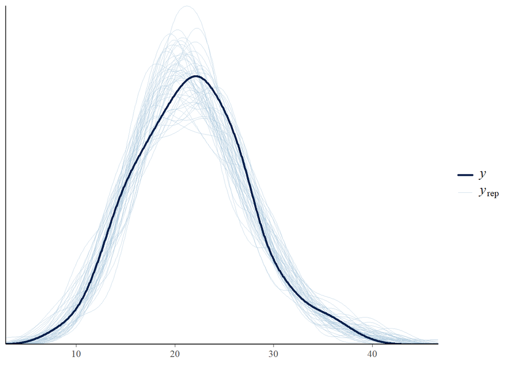

```r
pp_check(ref_fit)
```

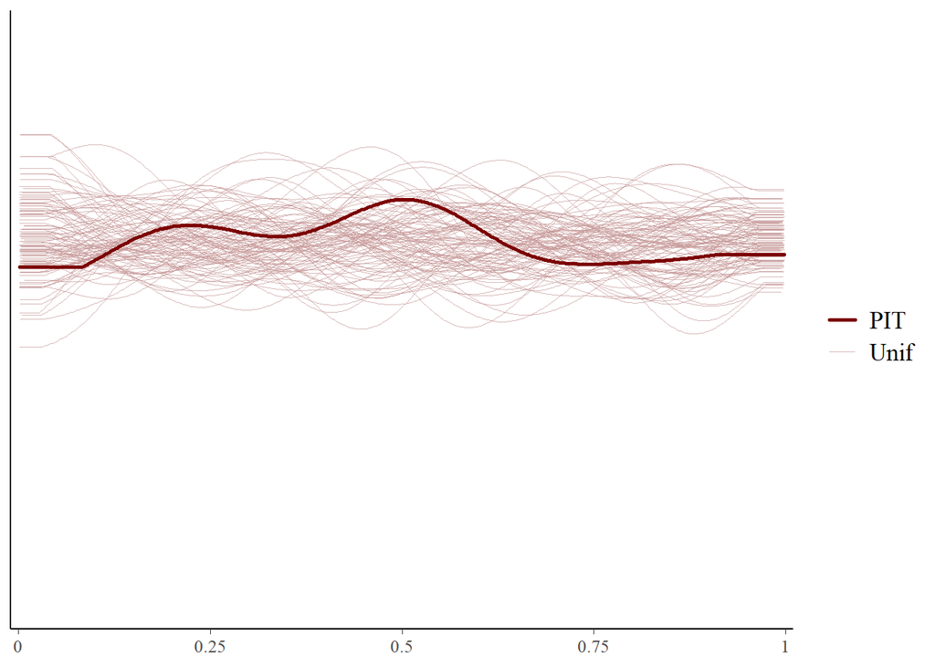

```r
y_rep_rmf <- posterior_predict(ref_fit)
loo_rmf <- loo(ref_fit , save_psis = TRUE, cores = 4)
psis1_rmf <- loo_rmf$psis_object
lw_rmf <- weights(psis1_rmf)
color_scheme_set("red")

ppc_loo_pit_overlay(y = women$Fat,yrep=y_rep_rmf,lw=lw_rmf)
```

```r
# Summarize the posterior distributions simple model
summary_rmf_cv <- prediction_summary_cv(model = ref_fit , data = women, k = 3)

# Print the summary simple model
print(summary_rmf_cv)
```

```
$folds
  fold      mae mae_scaled within_50 within_95
1    1 2.613505  0.7324446 0.4677419 0.9193548
2    2 2.246639  0.6230050 0.5409836 0.9180328
3    3 2.906739  0.7604528 0.4098361 0.9672131

$cv
       mae mae_scaled within_50 within_95
1 2.588961  0.7053008 0.4728539 0.9348669
```

The reference model passes the checks and therefore I decide to use this model, because it predicts well. In a next step I use the `projpred`-algorithms to find a simpler model that gives similar predictions as the reference model. In `projpred`, in the case of **L1-regularized search**, coefficients are estimated over a grid of penalization values using the reference model’s fit in place of the observed response. This produces a sequence of sparse models ranked by the order in which variables enter with non-zero coefficients as the penalty decreases. Importantly, penalization is only used for variable ranking; submodels are later refit using projections without penalization.

To evaluate predictor stability, the search procedure is repeated across data subsets. **In this re-analysis,** **leave-one-out cross-validation (LOO)** **is used in combination with** **L1 search** **as the primary strategy (`LOO-L1`).** Additionally, 5-fold cross-validation is implemented to assess the **robustness** of variable selection and predictive performance. In cross-validation mode, selection is performed on training folds, and performance is evaluated on held-out test data. Results are also computed based on forward excursion, in combination with LOO-CV and 5-fold-CV. (See Sensitivity of Selection at the bottom of this file.)

Finally, output visualizations report the proportion of times each variable was selected. If `cumulate = FALSE`, proportions reflect selection at specific ranking positions. If `cumulate = TRUE`, they capture cumulative inclusion up to each rank, as annotated in the “CV ranking proportions matrix” plot.

## 2.2 **Objective 1.1: Predictive Projections: L1 search, LOO**

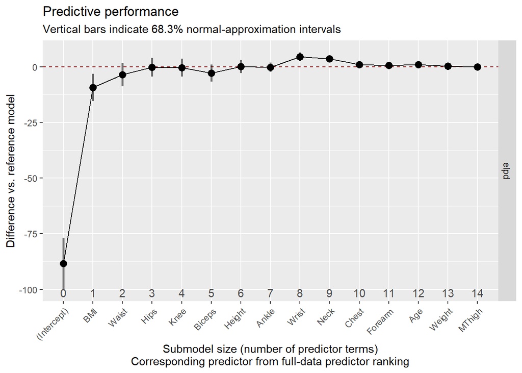

```r
# Generate model path: By varying lambda, a sequence of submodels with an increasing number of (non-zero) coefficients is created. ➤ The order in which coefficients “appear” serves as a ranking of the variables.

set.seed(2341)
vs_cvl <- cv_varsel(object = ref_fit, method = 'L1',  cv_method = 'loo', validate_search = TRUE, verbose = FALSE)

save(vs_cvl,file = file.path(PPath,"vs_cvl"))
#load(file = file.path(PPath,"vs_cvl"))

plot(vs_cvl, deltas = TRUE, stats =  c('elpd'))
```

## 2.3 **Objective 1.2:** Model stability: Stability of predictive projection

L1 Search (LOO)

```
 Summary of variable selection:

Family: gaussian
Link function: identity

Formula: Fat ~ Weight + Height + BMI + Age + Neck + Chest + Biceps + Hips +
    Waist + Forearm + MThigh + Wrist + Knee + Ankle
Observations: 184
Projection method: traditional
CV method: PSIS-LOO CV with search included (i.e., fold-wise searches)
Search method: L1
Maximum submodel size for the search: 14
Number of projected draws in the search: 1 (from clustered projection)
Number of projected draws in the performance evaluation: 400
Argument `refit_prj`: TRUE

Submodel performance evaluation summary with `deltas = FALSE` and `cumulate = FALSE`:
 size ranking_fulldata cv_proportions_diag elpd elpd.se elpd.diff elpd.diff.se
    0      (Intercept)                  NA -585     9.1   -88.459        11.53
    1              BMI                1.00 -506     9.1    -9.256         6.06
    2            Waist                1.00 -500     8.6    -3.558         5.24
    3             Hips                1.00 -497     8.7    -0.148         4.22
    4             Knee                1.00 -497     8.7    -0.378         4.07
    5           Biceps                0.96 -500     9.1    -2.833         3.79
    6           Height                0.95 -497     9.7     0.173         2.92
    7            Ankle                0.95 -497    10.1    -0.227         2.13
    8            Wrist                0.95 -492     9.7     4.560         1.90
    9             Neck                0.99 -493     9.9     3.648         1.49
   10            Chest                0.93 -496    10.3     0.963         1.09
   11          Forearm                0.89 -496    10.5     0.709         0.91
   12              Age                0.86 -496    10.4     1.015         0.85
   13           Weight                0.70 -497    10.4     0.253         0.70
   14           MThigh                0.69 -497    10.4    -0.076         0.21

Reference model performance evaluation summary with `deltas = FALSE`:
   elpd elpd.se
   -497      10

️ Visualization of selection process:
```

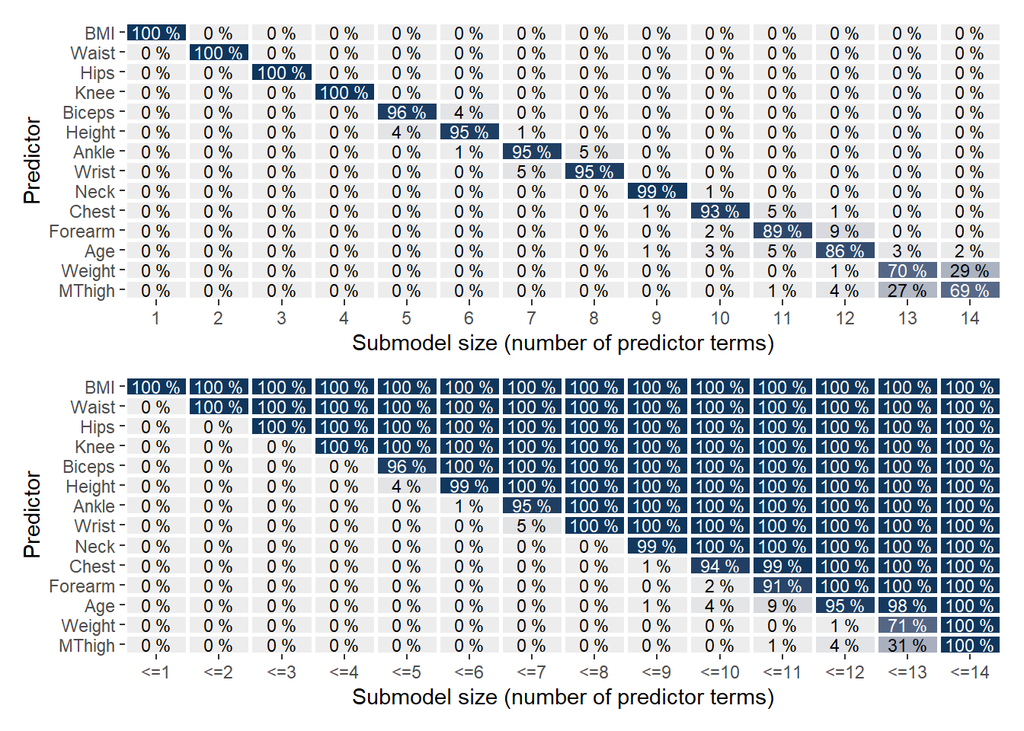

```
 Cumulative selection proportions (Top 5):
     predictor
size  BMI Waist Hips Knee Biceps Height Ankle Wrist Neck Chest Forearm Age
  <=5   1     1    1    1  0.957  0.043     0     0    0     0       0   0
     predictor
size  Weight MThigh
  <=5      0      0

 Suggested model size:
[1] 2

 Full ranking table:
 [1] "BMI"     "Waist"   "Hips"    "Knee"    "Biceps"  "Height"  "Ankle"
 [8] "Wrist"   "Neck"    "Chest"   "Forearm" "Age"     "Weight"  "MThigh"

 Terms selected (suggested size = 2):
[1] "BMI"   "Waist"

 Top 5 ranked terms:
[1] "BMI"    "Waist"  "Hips"   "Knee"   "Biceps"
```

```r
key_results <- inspect_variable_selection(vs_cvl, top_n = 5)
```

Show selected predictors

```r
solterms_final_fivel <- key_results$top_terms

print(solterms_final_fivel)
```

```
[1] "BMI"    "Waist"  "Hips"   "Knee"   "Biceps"
```

# 3 **Compute Projected Posterior: Post-selection-inference for L1 Search (LOO)**

Here post-selection inference starts, thus the results retain the uncertainty from the reference model posterior.

```r
# https://cran.r-project.org/web/packages/projpred/vignettes/projpred.html#post-selection-inference
proj_ref_fit <- project(vs_cvl, predictor_terms = solterms_final_fivel, ns = 4000)
```

## 3.1 Model description

Standardized coefficients based on the standard deviation of partial linear predictors, thus scaled coefficients (β · SD(X)).

```r
#set.seed(1234)
set.seed(5734)
# assemble data
results_beta <- matrix(0, nrow = 6 , ncol  = 5)
rownames(results_beta) <- c("(Intercept)",solterms_final_fivel)
colnames(results_beta) <- c("Regression coefficient", "Standardized beta", "Cum. proportions <=5", "2.5% PD-quantile", "97.5% PD-quantile")

mat <- as.matrix(proj_ref_fit)
beta <- mat[, 1:(ncol(mat) - 1)]

# Transform matrix to draws format (optional, for posterior-friendly summaries)
draws1 <- posterior::as_draws_matrix(beta)

summary_tbl <- summarise_draws(draws1, mean,  median, ~ quantile(.x, probs = c(0.025, 0.975)))

#str(summary_tbl)
# Compute standard deviations (excluding the first two columns) for women dataset
sd_women <- apply(women[, -c(1,2)], 2, sd)
vars_to_select <- key_results$top_terms
sd_selected <- sd_women[intersect(vars_to_select, names(sd_women))]

std_coef <- summary_tbl$mean[2:6] * (sd_selected)
std_coef <- c(summary_tbl$mean[1],std_coef)

results_beta[,1] <- round(summary_tbl$mean,3)
results_beta[,2] <- round(std_coef,3)
results_beta[,3] <- round(c(1.0,key_results$cumprop[1:5]),3)
results_beta[,4] <- round(summary_tbl$`2.5%`,3)
results_beta[,5] <- round(summary_tbl$`97.5%`,3)


results_beta <- results_beta[order(-abs(results_beta[,3])),]
kable(results_beta, format="html", caption="Regression coefficients and stability measures")
```

Regression coefficients and stability measures

|  | Regression coefficient | Standardized beta | Cum. proportions <=5 | 2.5% PD-quantile | 97.5% PD-quantile |
| --- | --- | --- | --- | --- | --- |
| (Intercept) | -35.621 | -35.621 | 1.000 | -47.646 | -25.367 |
| BMI | 0.727 | 1.963 | 1.000 | 0.302 | 1.164 |
| Waist | 0.209 | 1.344 | 1.000 | 0.050 | 0.364 |
| Hips | 0.164 | 1.003 | 1.000 | 0.013 | 0.318 |
| Knee | 0.249 | 0.539 | 1.000 | -0.159 | 0.645 |
| Biceps | 0.088 | 0.217 | 0.957 | -0.274 | 0.437 |

Global model descriptors:

Model performance was assessed using multiple complementary measures. The correlation-based $R^2$ is defined as the squared Pearson correlation between observed outcomes and predicted linear predictors and can be interpreted as an unadjusted measure of explained variance. This measure is reported separately, as does not have an associated posterior distribution.

Additionally, the Bayesian $R^2$ proposed by Gelman et al. was computed. This measure captures explained variance while accounting for posterior uncertainty and is conceptually related to an adjusted $R^2$. The residual error ($\sigma$) quantifies the unexplained variability in the outcome. Both the Bayesian $R^2$ and $\sigma$ are derived from posterior distributions and are therefore reported with corresponding summary statistics (mean, median, and credible intervals), whereas the correlation-based $R^2$ is not.

Bootstrap-based performance metrics were not considered, as predictive projection was employed. This approach separates variable selection from model validation, thereby reducing the risk of overfitting. Moreover, post-selection inference was used to propagate uncertainty from the original reference model to the reduced model.

```r
# --- 1. Linear predictors from projection ---
y_linpred_female <- proj_linpred(proj_ref_fit, newdata = women)
women2 <- cbind(women, linpred = colMeans(y_linpred_female$pred))

# --- 2. Correlation-based R² (reported separately) ---
R_square <- cor(women2$linpred, women2$Fat)^2

# --- 3. Posterior draws ---
draws1b <- posterior::as_draws_matrix(mat)

summary_tbl_1b <- posterior::summarise_draws(
  draws1b,
  mean,
  median,
  ~quantile(.x, probs = c(0.05, 0.95))
)

# --- 4. Extract sigma ---
summary_sigma <- summary_tbl_1b %>% dplyr::filter(variable == "sigma")
sigma_draws <- as.numeric(draws1b[, "sigma"])

# --- 5. Bayesian R² ---
r2_values <- bayes_r2(
  ypred = y_linpred_female$pred,
  y = women2$Fat
)

# --- 6. Design matrix based on selected predictors ---
formula_proj <- as.formula(
  paste("~", paste(solterms_final_fivel, collapse = " + "))
)

X <- model.matrix(formula_proj, data = women)

# --- 7. Compute mean quadratic term ---
XtX_inv <- solve(t(X) %*% X)
quad_terms <- rowSums((X %*% XtX_inv) * X)
mean_quad <- mean(quad_terms)

# --- 8. Model-based RMSE (posterior) ---
rmse_fitted_draws <- sigma_draws * sqrt(mean_quad)


rmse_summary <- c(
  mean = mean(rmse_fitted_draws),
  median = median(rmse_fitted_draws),
  `5%` = unname(quantile(rmse_fitted_draws, 0.05)),
  `95%` = unname(quantile(rmse_fitted_draws, 0.95))
)

# --- 9. Final table ---
final_table <- data.frame(
  Measure = c(
    "Residual error (σ)",
    "Bayesian R²",
    "RMSE fitted (model-based)"
  ),

  Mean = c(
    as.numeric(summary_sigma$mean),
    mean(r2_values),
    as.numeric(rmse_summary["mean"])
  ),

  Median = c(
    as.numeric(summary_sigma$median),
    median(r2_values),
    as.numeric(rmse_summary["median"])
  ),

  `Lower 5%` = c(
    as.numeric(summary_sigma$`5%`),
    quantile(r2_values, 0.05),
    as.numeric(rmse_summary["5%"])
  ),

  `Upper 95%` = c(
    as.numeric(summary_sigma$`95%`),
    quantile(r2_values, 0.95),
    as.numeric(rmse_summary["95%"])
  ),

  check.names = FALSE
)

knitr::kable(final_table,
             digits = 3,
             caption = "Global model performance measures") %>%
  kableExtra::kable_styling(full_width = FALSE)
```

Global model performance measures

| Measure | Mean | Median | Lower 5% | Upper 95% |
| --- | --- | --- | --- | --- |
| Residual error (σ) | 3.708 | 3.704 | 3.409 | 4.064 |
| Bayesian R² | 0.634 | 0.636 | 0.589 | 0.669 |
| RMSE fitted (model-based) | 0.670 | 0.669 | 0.616 | 0.734 |

```r
# Separate output for correlation-based R^2
cat("\nCorrelation-based R² (unadjusted): ", round(R_square, 3), "\n")
```

```
Correlation-based R² (unadjusted):  0.638
```

## 3.2 Assumptions and diagnostics: residual analysis

```r
print("Five active predictors")
```

```
[1] "Five active predictors"
```

```r
active_predictors <- solterms_final_fivel
active_predictors
```

```
[1] "BMI"    "Waist"  "Hips"   "Knee"   "Biceps"
```

```r
print("Eight ext. active predictors")
```

```
[1] "Eight ext. active predictors"
```

```r
active_predictors_ext <- key_results$full_ranking[1:8]
active_predictors_ext
```

```
[1] "BMI"    "Waist"  "Hips"   "Knee"   "Biceps" "Height" "Ankle"  "Wrist"
```

```r
p <- length(predictors)

x <- as.matrix(women[, predictors])
y <- as.numeric(women$Fat)
n <- nrow(x)
```

```r
predictions <- women2$linpred
y <- women2$Fat
# Compute residuals
prj_predictW <- proj_predict(proj_ref_fit)

qres.m1 = createDHARMa(simulatedResponse = t(prj_predictW),
                          observedResponse = women2$Fat,
                          fittedPredictedResponse = apply(prj_predictW, 2, median), integerResponse = F, seed = 123, method = "PIT")
# uniform distributed residuals
print("Uniform residuals")
```

```
[1] "Uniform residuals"
```

```r
summary(residuals(qres.m1))
```

```
   Min. 1st Qu.  Median    Mean 3rd Qu.    Max.
 0.0050  0.2600  0.4900  0.4995  0.7325  1.0000
```

```r
# transform to normal scale
residuals <- qnorm(residuals(qres.m1))
print("Normal residuals")
```

```
[1] "Normal residuals"
```

```r
summary(residuals)
```

```
    Min.  1st Qu.   Median     Mean  3rd Qu.     Max.
-2.57583 -0.64335 -0.02507      Inf  0.62045      Inf
```

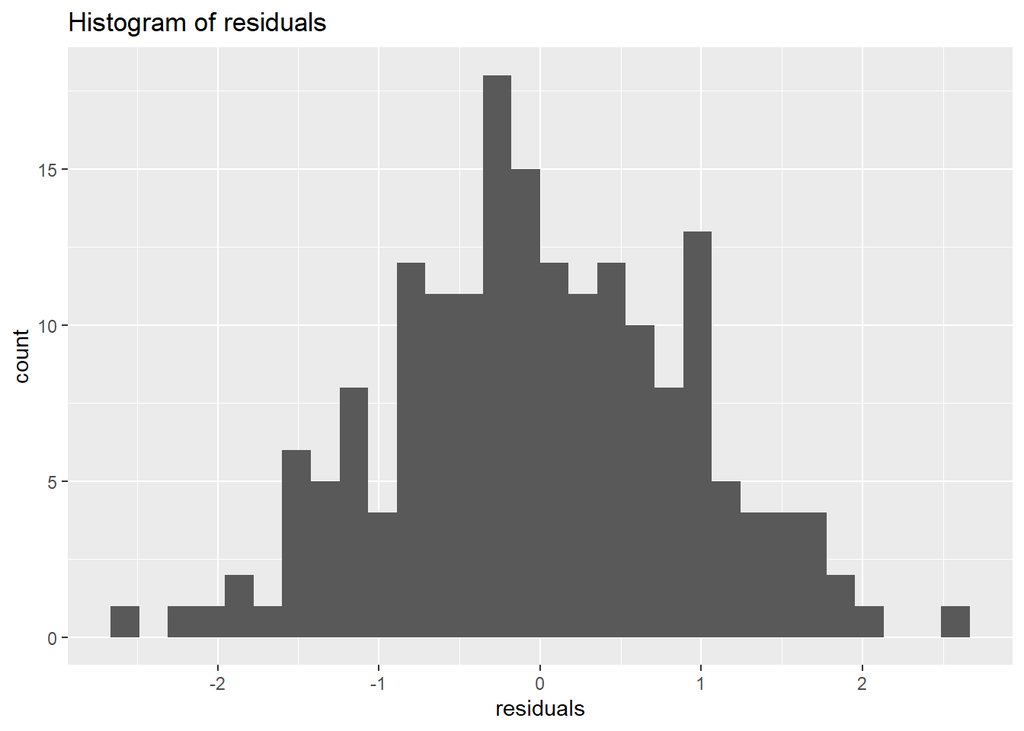

```r
ggplot(data=data.frame(residuals), aes(x=residuals)) + geom_histogram() + ggtitle(label="Histogram of residuals")
```

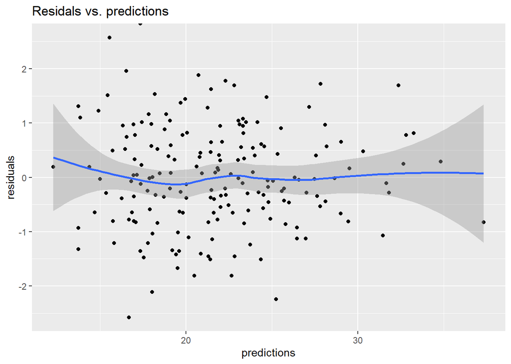

```r
sqrt_abs_res <- sqrt(abs(residuals))

ggplot(data=data.frame(residuals, predictions, y), aes(x=predictions, y=residuals)) + geom_point() + geom_smooth() + ggtitle(label="Residals vs. predictions")
```

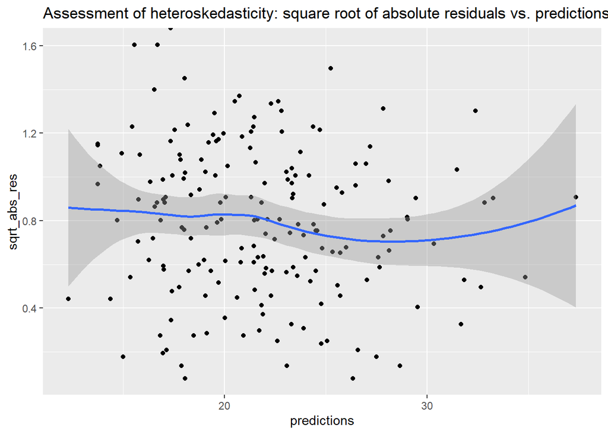

```r
ggplot(data=data.frame(sqrt_abs_res, predictions, y), aes(x=predictions, y=sqrt_abs_res)) + geom_point() + geom_smooth() + ggtitle(label="Assessment of heteroskedasticity: square root of absolute residuals vs. predictions")
```

In the following residual plots, the nearly-selected predictors are denoted by red dots, the selected predictors by blue dots.

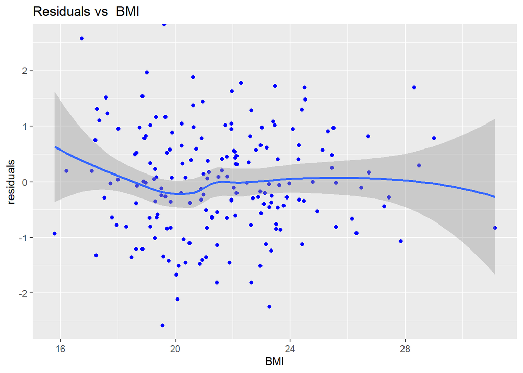

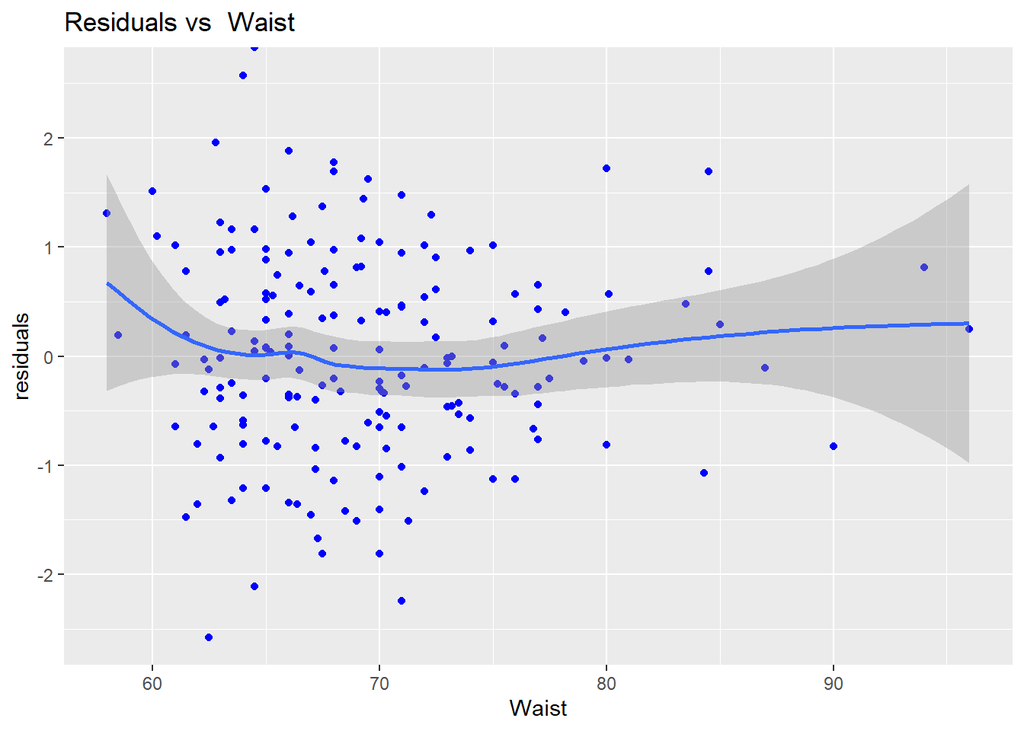

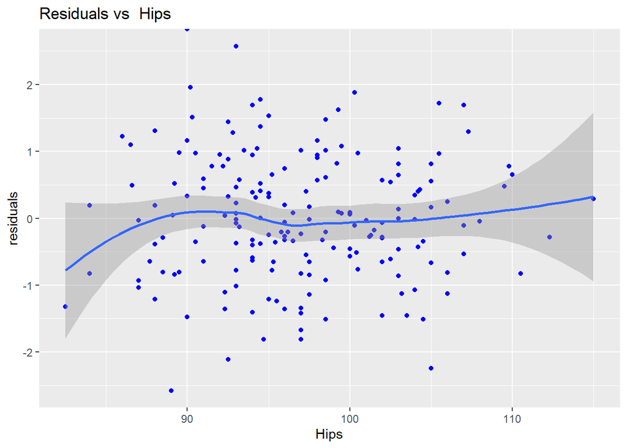

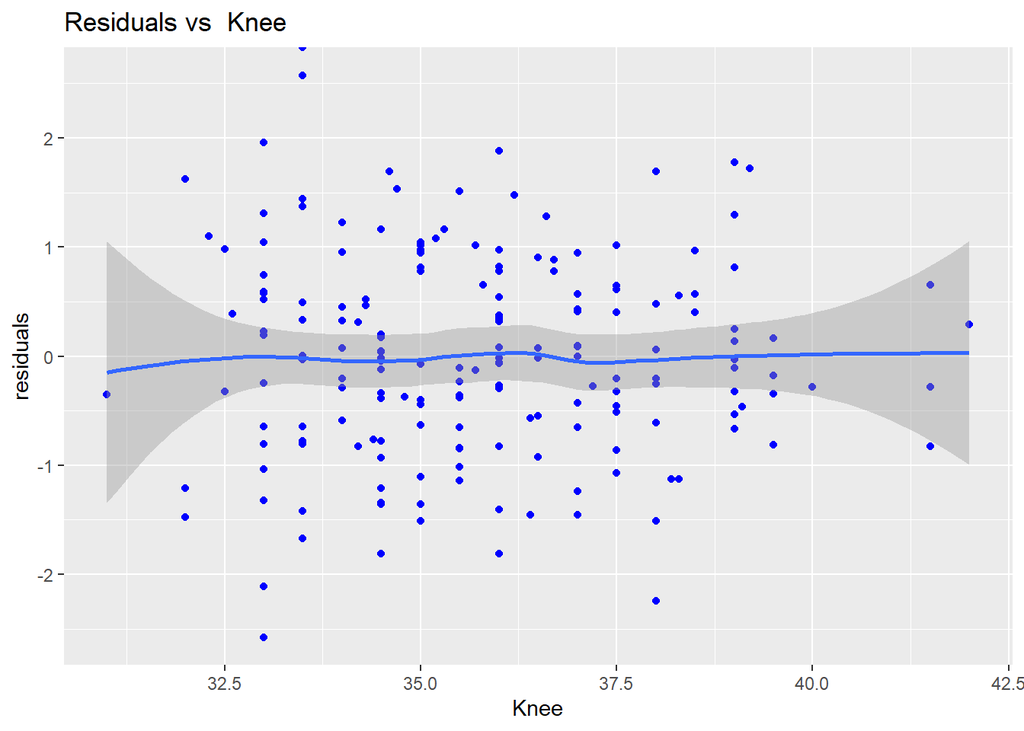

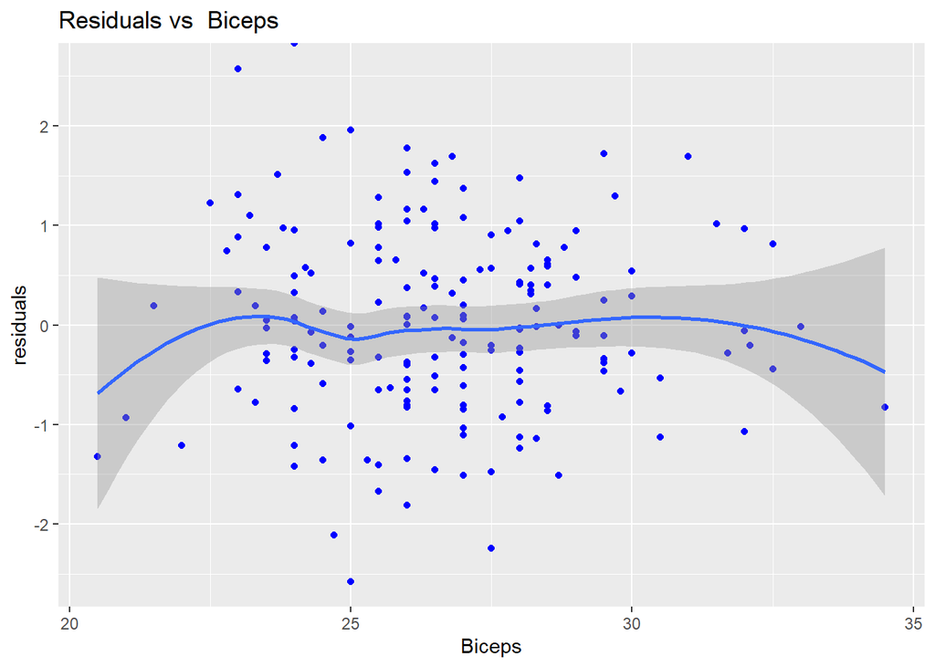

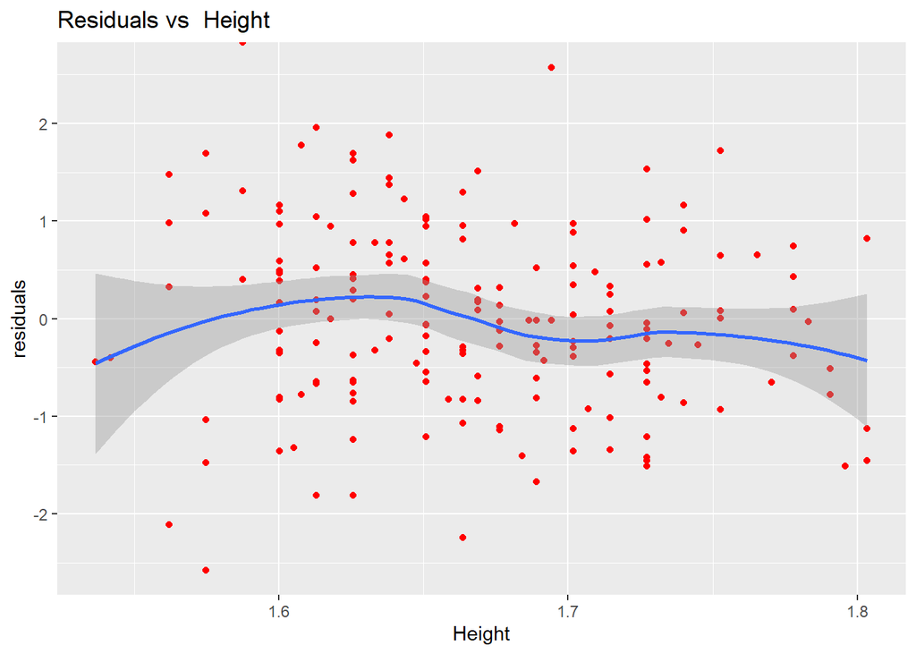

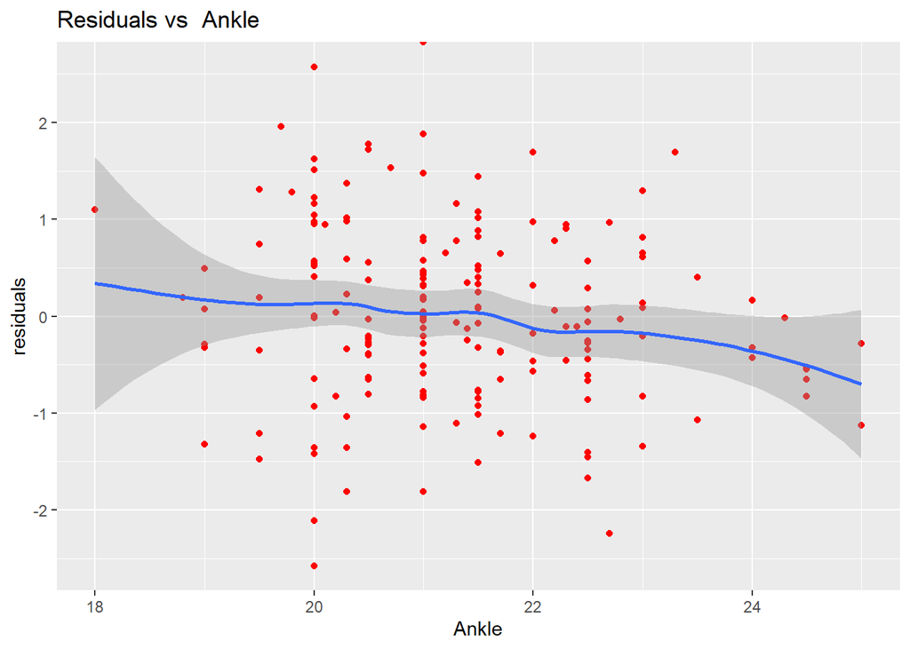

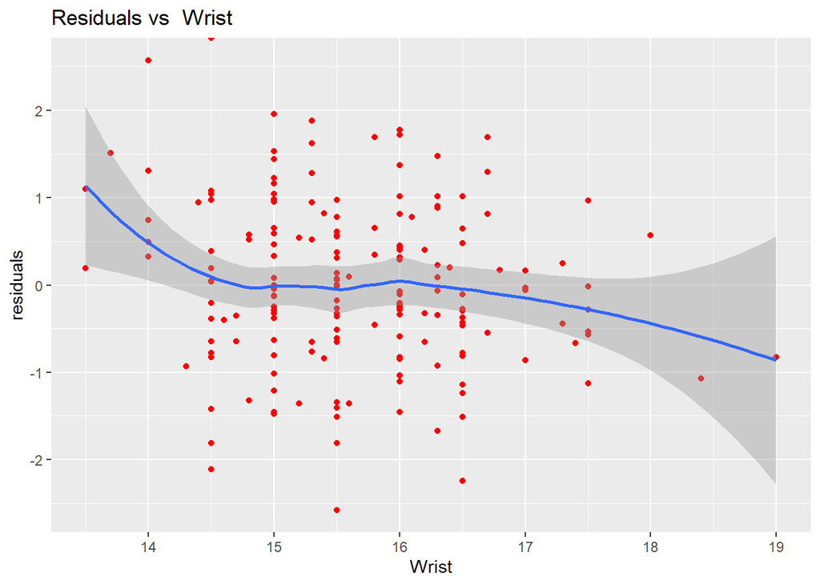

```r
for(v in active_predictors_ext){
  cols=ifelse(v %in% active_predictors, "blue", "red")
  print(ggplot(data=data.frame(residuals, variable=x[,v]), aes(x=variable, y=residuals), xlab(v)) + geom_point(color=cols) + geom_smooth() + xlab(v) + ggtitle(label=paste("Residuals vs ",v, collapse="")))
  }
```

# 4 Objective 2: Model validation

```r
# ------------------------------------------------------------
# Validation of predictive performance in the men's dataset
# ------------------------------------------------------------
# This code evaluates predictive performance of a Bayesian
# projected model using posterior predictive draws.
# Two metrics are computed as full posterior distributions:
#
# 1. Bayesian R² (distribution over posterior draws)
# 2. Root Mean Squared Prediction Error (RMSPE, distribution)
#
# For each metric, mean, median, and 5%/95% quantiles are
# reported in a summary table.
# ------------------------------------------------------------

# --- 1. Posterior predictive linear predictors ---
y_linpred_male <- proj_linpred(proj_ref_fit, newdata = men)

# Observed outcome
ymen <- men$Fat

# --- 2. Bayesian R² (posterior distribution) ---
r2_values_men <- bayes_r2_ext(
  ypred = y_linpred_male$pred,
  y = ymen
)

# --- 3. RMSPE (posterior distribution over draws) ---
rmspe_draws <- apply(y_linpred_male$pred, 1, function(pred_row) {
  sqrt(mean((ymen - pred_row)^2))
})

# --- 4. Helper function to summarise distributions ---
summarise_dist <- function(x) {
  c(
    mean = mean(x),
    median = median(x),
    `5%` = quantile(x, 0.05),
    `95%` = quantile(x, 0.95)
  )
}



# --- 5. Final validation table ---
summarise_dist <- function(x) {
  c(
    mean = mean(x),
    median = median(x),
    `5%` = unname(quantile(x, 0.05)),
    `95%` = unname(quantile(x, 0.95))
  )
}

summary_r2 <- summarise_dist(r2_values_men)
summary_rmspe <- summarise_dist(rmspe_draws)

validation_table_men <- data.frame(
  Measure = c("Validation R²", "Root Mean Squared Prediction Error"),

  Mean = c(
    summary_r2["mean"],
    summary_rmspe["mean"]
  ),

  Median = c(
    summary_r2["median"],
    summary_rmspe["median"]
  ),

  `Lower 5%` = c(
    summary_r2["5%"],
    summary_rmspe["5%"]
  ),

  `Upper 95%` = c(
    summary_r2["95%"],
    summary_rmspe["95%"]
  ),

  check.names = FALSE
)

knitr::kable(validation_table_men,
             digits = 3,
             caption = "Predictive validation performance (men, posterior distributions)") %>%
  kableExtra::kable_styling(full_width = FALSE)
```

Predictive validation performance (men, posterior distributions)

| Measure | Mean | Median | Lower 5% | Upper 95% |
| --- | --- | --- | --- | --- |
| Validation R² | -1.507 | -1.497 | -2.323 | -0.795 |
| Root Mean Squared Prediction Error | 13.180 | 13.219 | 11.208 | 15.247 |

Calibration plot:

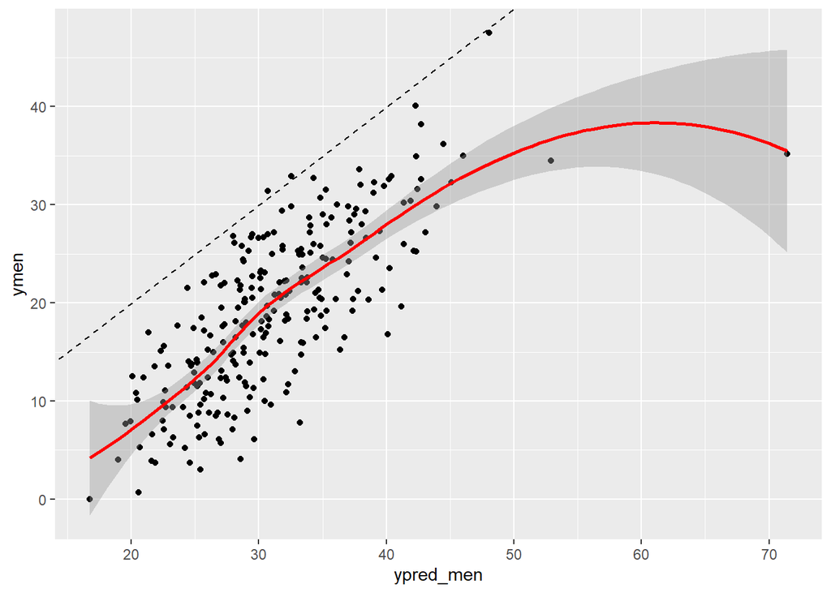

```r
# Calibration plot
ypred_men <- colMeans(y_linpred_male$pred)
ggplot(data.frame(ypred_men, ymen), aes(x=ypred_men, y=ymen)) + geom_point() + geom_smooth(col="red") + geom_abline(intercept=0, slope=1, linetype="dashed")
```

Calibration model:

```r
observed <- men$Fat
predicted <- ypred_men
calib_data <- data.frame(observed = observed, predicted = predicted)
# Compute calibration intercept and slope
calibration_model <- stan_glm(observed ~ predicted, family = gaussian(), data = calib_data)
calibration_model0 <- stan_glm(observed ~ offset(predicted), family = gaussian(), data = calib_data)
```

```r
summary(calibration_model)
```

```
Model Info:
 function:     stan_glm
 family:       gaussian [identity]
 formula:      observed ~ predicted
 algorithm:    sampling
 sample:       4000 (posterior sample size)
 priors:       see help('prior_summary')
 observations: 252
 predictors:   2

Estimates:
              mean   sd    10%   50%   90%
(Intercept) -10.6    1.7 -12.8 -10.6  -8.3
predicted     1.0    0.1   0.9   1.0   1.0
sigma         5.6    0.3   5.2   5.5   5.9

Fit Diagnostics:
           mean   sd   10%   50%   90%
mean_PPD 19.1    0.5 18.5  19.2  19.8

The mean_ppd is the sample average posterior predictive distribution of the outcome variable (for details see help('summary.stanreg')).

MCMC diagnostics
              mcse Rhat n_eff
(Intercept)   0.0  1.0  3664
predicted     0.0  1.0  3606
sigma         0.0  1.0  3642
mean_PPD      0.0  1.0  4121
log-posterior 0.0  1.0  1703

For each parameter, mcse is Monte Carlo standard error, n_eff is a crude measure of effective sample size, and Rhat is the potential scale reduction factor on split chains (at convergence Rhat=1).
```

```r
summary(calibration_model0)
```

```
Model Info:
 function:     stan_glm
 family:       gaussian [identity]
 formula:      observed ~ offset(predicted)
 algorithm:    sampling
 sample:       4000 (posterior sample size)
 priors:       see help('prior_summary')
 observations: 252
 predictors:   1

Estimates:
              mean   sd    10%   50%   90%
(Intercept) -11.9    0.3 -12.4 -11.9 -11.5
sigma         5.6    0.2   5.2   5.5   5.9

Fit Diagnostics:
           mean   sd   10%   50%   90%
mean_PPD 19.1    0.5 18.5  19.2  19.8

The mean_ppd is the sample average posterior predictive distribution of the outcome variable (for details see help('summary.stanreg')).

MCMC diagnostics
              mcse Rhat n_eff
(Intercept)   0.0  1.0  2621
sigma         0.0  1.0  2767
mean_PPD      0.0  1.0  3384
log-posterior 0.0  1.0  1548

For each parameter, mcse is Monte Carlo standard error, n_eff is a crude measure of effective sample size, and Rhat is the potential scale reduction factor on split chains (at convergence Rhat=1).
```

```r
posterior_samples <- as.matrix(calibration_model)
posterior_samples0 <- as.matrix(calibration_model0)
intercepts <- posterior_samples0[, "(Intercept)"]
slopes <- posterior_samples[, "predicted"]

cal_slope <- mean(slopes)
conf_slope <- quantile(posterior_samples[, "predicted"], probs = c(0.025,  0.975))
cal_int <- mean(intercepts)
conf_int <- quantile(posterior_samples0[, "(Intercept)"], probs = c(0.025,  0.975))

cal_stats <- c(cal_int, conf_int, cal_slope, conf_slope)

names(cal_stats) <- c("Calibration intercept", "Calibration intercept, lower 95% PD", "Calibration intercept, upper 95% PD", "Calibration slope", "Calibration slope, lower 95% PD", "Calibration slope, upper 95% PD")

kable(cal_stats, caption="Calibration statistics")
```

Calibration statistics

|  | x |
| --- | --- |
| Calibration intercept | -11.9234466 |
| Calibration intercept, lower 95% PD | -12.5835322 |
| Calibration intercept, upper 95% PD | -11.2387768 |
| Calibration slope | 0.9568385 |
| Calibration slope, lower 95% PD | 0.8501085 |
| Calibration slope, upper 95% PD | 1.0651125 |

```r
# Dataframe  for regression lines
regression_lines <- data.frame(
  intercept = intercepts,
  slope = slopes
)

n_lines <- nrow(as.matrix(calibration_model))
print(n_lines)
```

```
[1] 4000
```

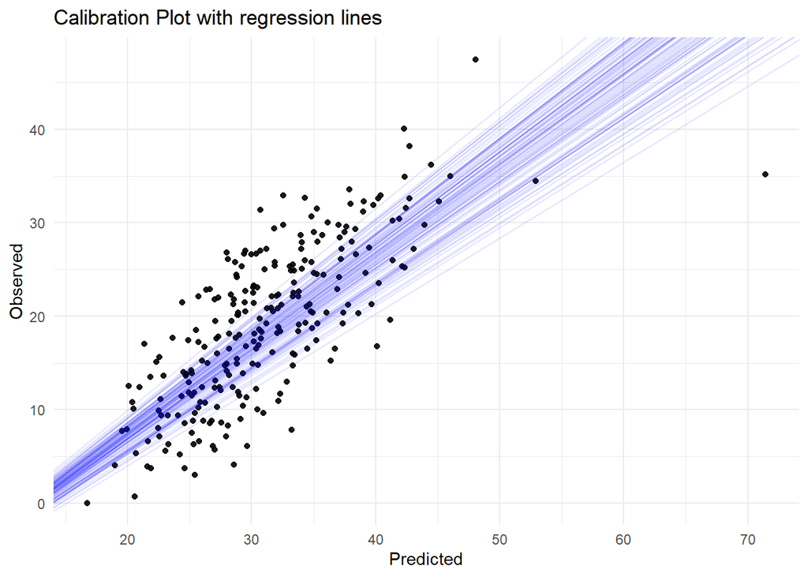

```r
sampled_lines <- regression_lines[sample(nrow(regression_lines), size = 100), ]
# plot
ggplot(calib_data, aes(x = predicted, y = observed)) +
  geom_point(alpha = 0.9) +
  geom_abline(data = sampled_lines, aes(intercept = intercept, slope = slope), alpha = 0.1, color = "blue") +
  labs(title = "Calibration Plot with regression lines",
       x = "Predicted",
       y = "Observed") +
  theme_minimal()
```

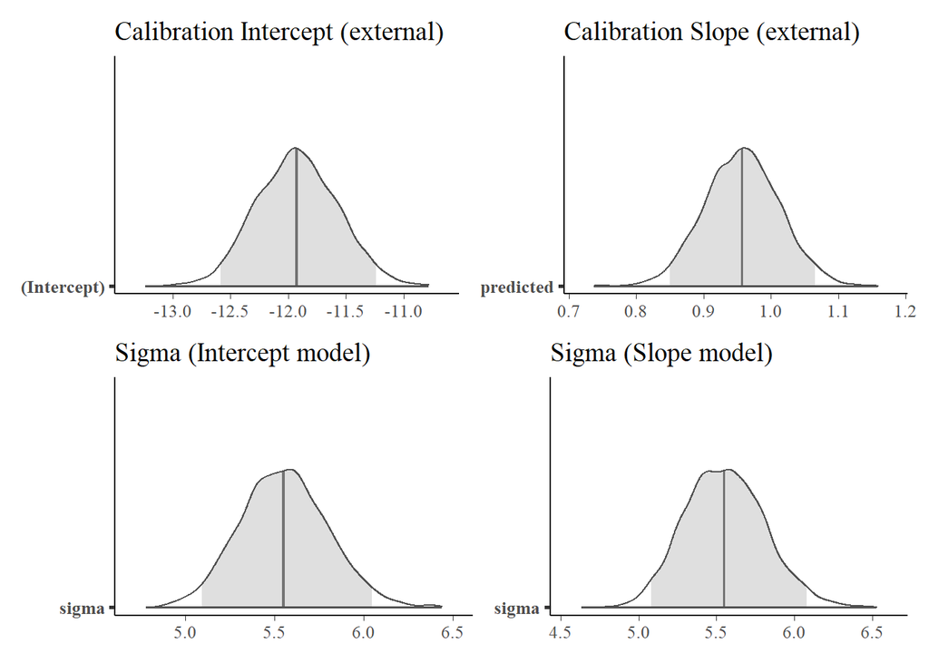

```r
color_scheme_set("gray")



(
  mcmc_areas(
    as.matrix(calibration_model0),
    pars = "(Intercept)",
    prob = 0.95
  ) +
    ggtitle("Calibration Intercept (external)")

  |

  mcmc_areas(
    as.matrix(calibration_model),
    pars = "predicted",
    prob = 0.95
  ) +
    ggtitle("Calibration Slope (external)")
) /
(
  mcmc_areas(
    as.matrix(calibration_model0),
    pars = "sigma",
    prob = 0.95
  ) +
    ggtitle("Sigma (Intercept model)")

  |

  mcmc_areas(
    as.matrix(calibration_model),
    pars = "sigma",
    prob = 0.95
  ) +
    ggtitle("Sigma (Slope model)")
)
```

```r
r2_values_men_extK  <- bayes_r2_ext(ypred = y_linpred_male$pred + intercepts, y = men$Fat)


summary_r2_men_extK  <- data.frame(
  mean   = round(mean(r2_values_men_extK),3),
  median = round(median(r2_values_men_extK),3),
  p05   = round(quantile(r2_values_men_extK, 0.05),3),
  p95   = round(quantile(r2_values_men_extK, 0.95),3)
)

rownames(summary_r2_men_extK) <- "R²"
colnames(summary_r2_men_extK)[colnames(summary_r2_men_extK) == "p05" ] <- "5%"
colnames(summary_r2_men_extK)[colnames(summary_r2_men_extK) ==  "p95" ] <- "95%"

kable(summary_r2_men_extK, digits = 3 , caption = "Cor. Validation R²  for men") %>%
  kable_styling(full_width = FALSE)
```

Cor. Validation R² for men

|  | mean | median | 5% | 95% |
| --- | --- | --- | --- | --- |
| R² | 0.523 | 0.537 | 0.421 | 0.579 |

The calibration slope is approximately 1.0, exactly 0.9568385, suggesting good predictive scaling. However, the intercept indicates a systematic overestimation of body fat in men by 11.9234466 percentage points.

To address this bias, a re-calibrated model adjusting the intercept by -11.9234466. could be proposed. This adjusted model yields an apparent ( R^2 ) of 0.523. The uncertainty of the ( R^2 )estimate is expressed through a posterior predictive interval, reflecting the range of plausible values based on the model and the observed data.

# 5 Sensitivity analysis: Variable selection and Stability

Before inspecting the results, the primary search strategy was set to LOO-L1 (leave-one-out cross-validation with L1-regularized search), as this most closely aligns with the original SAP. To assess the robustness of predictor selection, forward selection and 5-fold cross-validation were additionally computed, not as alternatives, but to evaluate whether they yield different sets of selected variables, thus to access the internal robustness.

## 5.1 **Predictive Projections: Forward search, LOO**

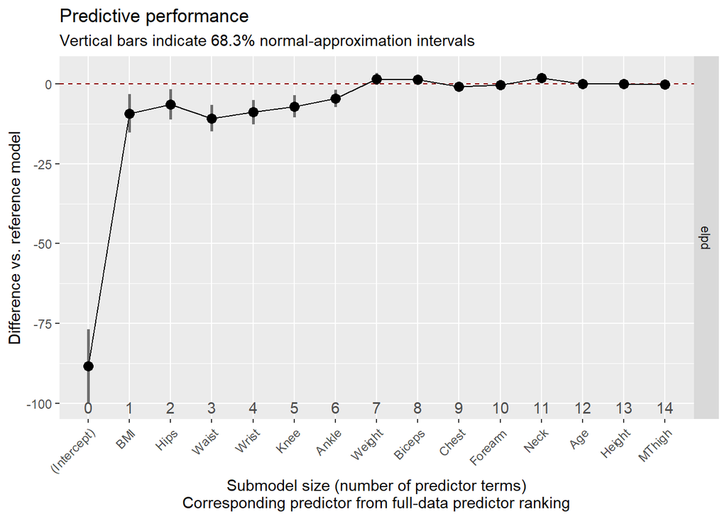

```r
set.seed(2341)
vs_cvf <- cv_varsel(object = ref_fit, method = 'forward', cv_method = 'loo', validate_search = TRUE, verbose = FALSE)
save(vs_cvf,file = file.path(PPath,"vs_cvf"))

plot(vs_cvf, deltas = TRUE, stats =  c('elpd'))
```

## 5.2 **Predictive Projection: Forward search, five-fold**

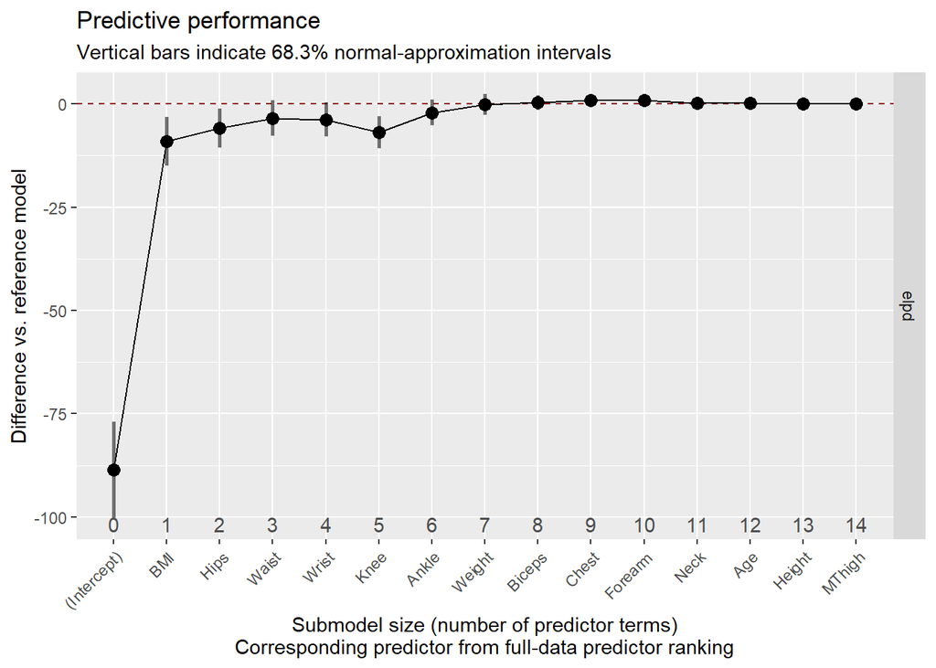

```r
set.seed(2341)
vs_cvf5 <- cv_varsel(object = ref_fit,  method = "forward",cv_method = "kfold",         K = 5,validate_search = TRUE, verbose = FALSE)
save(vs_cvf5,file = file.path(PPath,"vs_cvs"))

plot(vs_cvf5, deltas = TRUE, stats =  c('elpd'))
```

## 5.3 **Predictive Projections: L1 search, 5-fold**

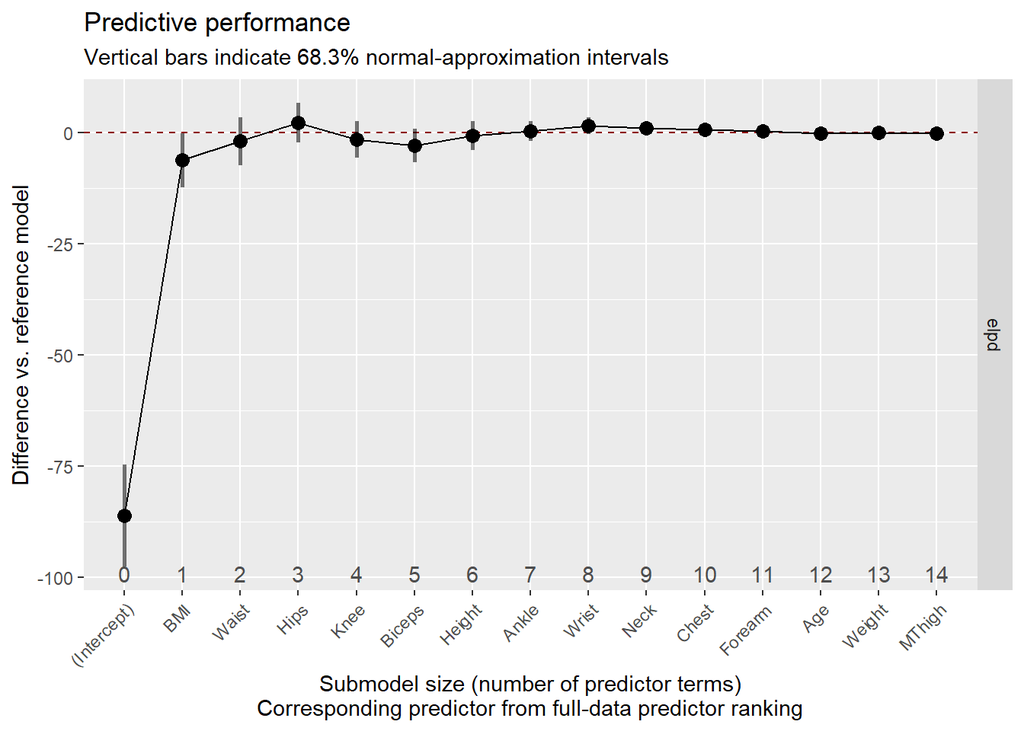

```r
set.seed(2341)
vs_cvl5 <- cv_varsel( object = ref_fit, method = 'L1',   cv_method = "kfold",K = 5, verbose = FALSE)
save(vs_cvl5,file = file.path(PPath,"vs_cvl5"))

# Plot the variable selection
plot(vs_cvl5, deltas = TRUE, stats =  c('elpd'))
```

## 5.4 Model stability: Stability of predictive projection

Forward Search (LOO)

```
 Summary of variable selection:

Family: gaussian
Link function: identity

Formula: Fat ~ Weight + Height + BMI + Age + Neck + Chest + Biceps + Hips +
    Waist + Forearm + MThigh + Wrist + Knee + Ankle
Observations: 184
Projection method: traditional
CV method: PSIS-LOO CV with search included (i.e., fold-wise searches)
Search method: forward
Maximum submodel size for the search: 14
Number of projected draws in the search: 20 (from clustered projection)
Number of projected draws in the performance evaluation: 400
Argument `refit_prj`: TRUE

Submodel performance evaluation summary with `deltas = FALSE` and `cumulate = FALSE`:
 size ranking_fulldata cv_proportions_diag elpd elpd.se elpd.diff elpd.diff.se
    0      (Intercept)                  NA -585     9.0   -88.312        11.46
    1              BMI                1.00 -506     9.0    -9.273         6.04
    2             Hips                0.98 -504     9.1    -6.441         4.80
    3            Waist                0.79 -508     9.7   -10.807         4.15
    4            Wrist                0.81 -506    10.1    -8.846         3.78
    5             Knee                0.84 -504    10.1    -7.047         3.42
    6            Ankle                0.77 -502    10.4    -4.498         2.71
    7           Weight                0.79 -496    10.0     1.523         1.90
    8           Biceps                0.98 -496    10.1     1.365         1.51
    9            Chest                0.84 -498    10.2    -0.813         1.33
   10          Forearm                0.89 -497    10.2    -0.262         1.02
   11             Neck                0.82 -495    10.2     1.923         0.71
   12              Age                0.15 -497    10.3     0.048         0.55
   13           Height                0.13 -497    10.4     0.040         0.37
   14           MThigh                0.95 -497    10.4    -0.183         0.34

Reference model performance evaluation summary with `deltas = FALSE`:
   elpd elpd.se
   -497      10

️ Visualization of selection process:
```

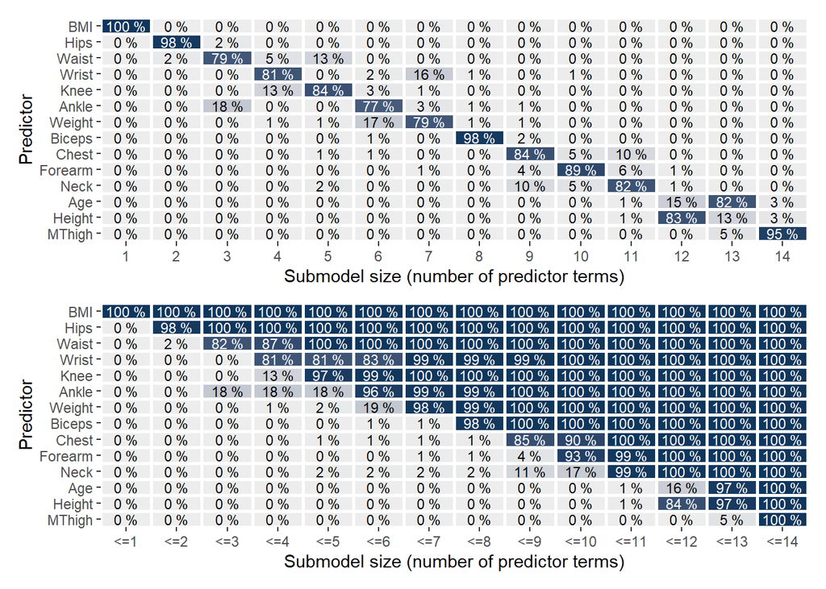

```
 Cumulative selection proportions (Top 5):
     predictor
size  BMI Hips Waist Wrist  Knee Ankle Weight Biceps Chest Forearm  Neck Age
  <=5   1    1     1  0.81 0.967 0.185  0.016      0 0.005       0 0.016   0
     predictor
size  Height MThigh
  <=5      0      0

 Suggested model size:
[1] 7

 Full ranking table:
 [1] "BMI"     "Hips"    "Waist"   "Wrist"   "Knee"    "Ankle"   "Weight"
 [8] "Biceps"  "Chest"   "Forearm" "Neck"    "Age"     "Height"  "MThigh"

 Terms selected (suggested size = 7):
[1] "BMI"    "Hips"   "Waist"  "Wrist"  "Knee"   "Ankle"  "Weight"

 Top 5 ranked terms:
[1] "BMI"   "Hips"  "Waist" "Wrist" "Knee"
```

```r
inspect_variable_selection(vs_cvf, top_n = 5)
```

Forward Search (5-fold)

```
 Summary of variable selection:

Family: gaussian
Link function: identity

Formula: Fat ~ Weight + Height + BMI + Age + Neck + Chest + Biceps + Hips +
    Waist + Forearm + MThigh + Wrist + Knee + Ankle
Observations: 184
Projection method: traditional
CV method: K-fold CV with K = 5 and search included (i.e., fold-wise searches)
Search method: forward
Maximum submodel size for the search: 14
Number of projected draws in the search: 20 (from clustered projection)
Number of projected draws in the performance evaluation: 400
Argument `refit_prj`: TRUE

Submodel performance evaluation summary with `deltas = FALSE` and `cumulate = FALSE`:
 size ranking_fulldata cv_proportions_diag elpd elpd.se elpd.diff elpd.diff.se
    0      (Intercept)                  NA -586     9.0   -88.645        11.64
    1              BMI                 1.0 -506     8.8    -9.074         5.82
    2             Hips                 0.8 -503     9.0    -5.918         4.75
    3            Waist                 0.6 -500     9.0    -3.493         4.28
    4            Wrist                 0.4 -501     9.2    -3.782         4.13
    5             Knee                 0.4 -504     9.8    -6.833         3.90
    6            Ankle                 0.2 -499     9.4    -2.142         3.12
    7           Weight                 0.2 -497     9.6    -0.166         2.58
    8           Biceps                 0.2 -497     9.8     0.316         1.76
    9            Chest                 0.4 -496     9.8     0.888         1.34
   10          Forearm                 0.2 -496    10.0     0.874         1.06
   11             Neck                 0.0 -497    10.1     0.239         0.58
   12              Age                 0.2 -497    10.2     0.205         0.53
   13           Height                 0.0 -497    10.2    -0.034         0.41
   14           MThigh                 0.0 -497    10.2     0.037         0.27

Reference model performance evaluation summary with `deltas = FALSE`:
   elpd elpd.se
   -497      10

️ Visualization of selection process:
```

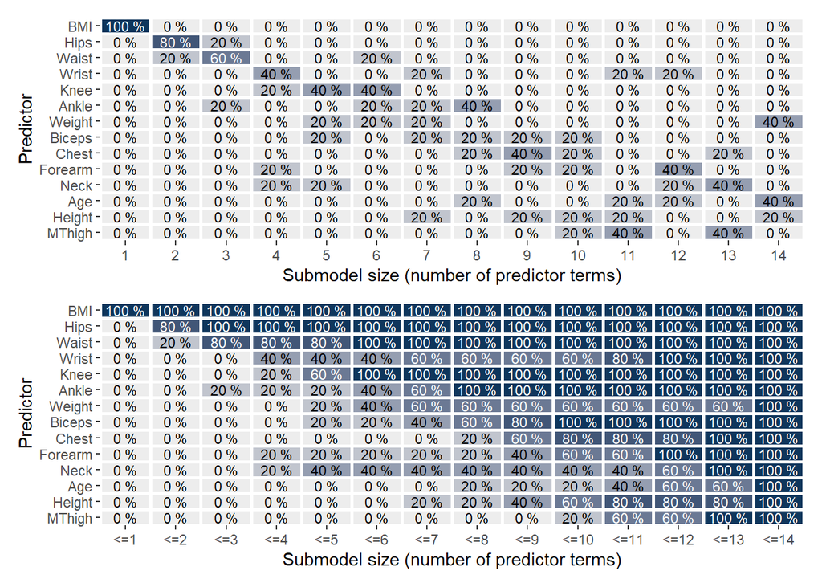

```
 Cumulative selection proportions (Top 5):
     predictor
size  BMI Hips Waist Wrist Knee Ankle Weight Biceps Chest Forearm Neck Age
  <=5   1    1   0.8   0.4  0.6   0.2    0.2    0.2     0     0.2  0.4   0
     predictor
size  Height MThigh
  <=5      0      0

 Suggested model size:
[1] 3

 Full ranking table:
 [1] "BMI"     "Hips"    "Waist"   "Wrist"   "Knee"    "Ankle"   "Weight"
 [8] "Biceps"  "Chest"   "Forearm" "Neck"    "Age"     "Height"  "MThigh"

 Terms selected (suggested size = 3):
[1] "BMI"   "Hips"  "Waist"

 Top 5 ranked terms:
[1] "BMI"   "Hips"  "Waist" "Wrist" "Knee"
```

```r
inspect_variable_selection(vs_cvf5, top_n = 5)
```

L1 Search (5-fold)

```
 Summary of variable selection:

Family: gaussian
Link function: identity

Formula: Fat ~ Weight + Height + BMI + Age + Neck + Chest + Biceps + Hips +
    Waist + Forearm + MThigh + Wrist + Knee + Ankle
Observations: 184
Projection method: traditional
CV method: K-fold CV with K = 5 and search included (i.e., fold-wise searches)
Search method: L1
Maximum submodel size for the search: 14
Number of projected draws in the search: 1 (from clustered projection)
Number of projected draws in the performance evaluation: 400
Argument `refit_prj`: TRUE

Submodel performance evaluation summary with `deltas = FALSE` and `cumulate = FALSE`:
 size ranking_fulldata cv_proportions_diag elpd elpd.se elpd.diff elpd.diff.se
    0      (Intercept)                  NA -586     9.1    -86.25        11.48
    1              BMI                 1.0 -506     8.7     -6.29         6.07
    2            Waist                 0.8 -502     8.4     -2.01         5.37
    3             Hips                 0.8 -498     8.4      2.15         4.50
    4             Knee                 0.8 -501     9.1     -1.54         4.10
    5           Biceps                 0.6 -503     9.5     -2.97         3.81
    6           Height                 0.4 -501     9.5     -0.72         3.26
    7            Ankle                 0.2 -500     9.8      0.27         2.25
    8            Wrist                 0.2 -498     9.6      1.42         1.89
    9             Neck                 0.0 -499    10.0      0.93         1.43
   10            Chest                 0.0 -499    10.3      0.56         1.24
   11          Forearm                 0.0 -500    10.4      0.26         1.03
   12              Age                 0.0 -500    10.3     -0.16         0.81
   13           Weight                 0.4 -500    10.5     -0.13         0.50
   14           MThigh                 0.0 -500    10.3     -0.24         0.21

Reference model performance evaluation summary with `deltas = FALSE`:
   elpd elpd.se
   -500      10

️ Visualization of selection process:
```

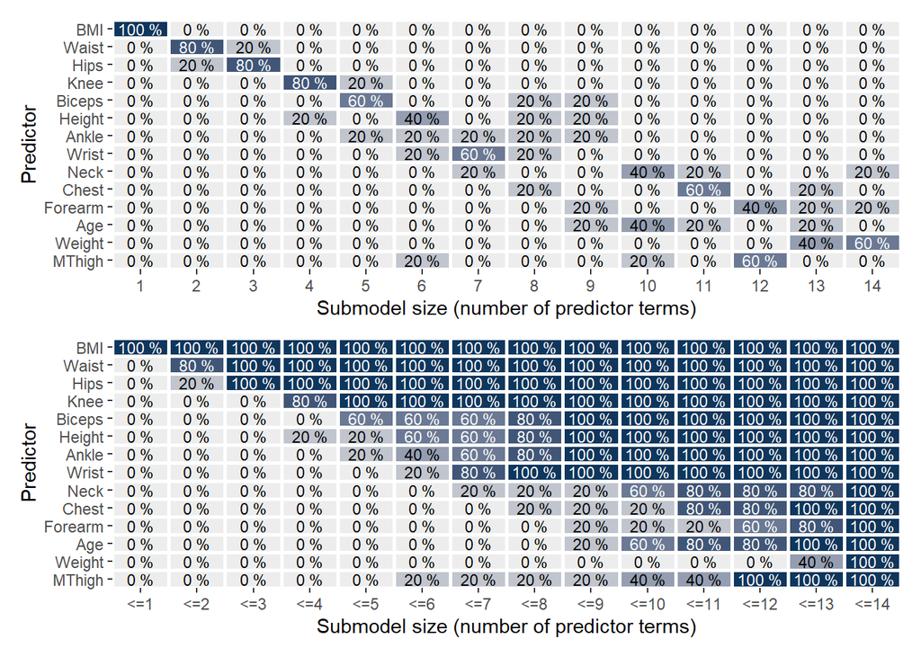

```
 Cumulative selection proportions (Top 5):
     predictor
size  BMI Waist Hips Knee Biceps Height Ankle Wrist Neck Chest Forearm Age
  <=5   1     1    1    1    0.6    0.2   0.2     0    0     0       0   0
     predictor
size  Weight MThigh
  <=5      0      0

 Suggested model size:
[1] 2

 Full ranking table:
 [1] "BMI"     "Waist"   "Hips"    "Knee"    "Biceps"  "Height"  "Ankle"
 [8] "Wrist"   "Neck"    "Chest"   "Forearm" "Age"     "Weight"  "MThigh"

 Terms selected (suggested size = 2):
[1] "BMI"   "Waist"

 Top 5 ranked terms:
[1] "BMI"    "Waist"  "Hips"   "Knee"   "Biceps"
```

```r
inspect_variable_selection(vs_cvl5, top_n = 5)
```